# Introducing NumPy's *ndarray*

[figure not shown]

# Who am I?

- Graduated with a BSc in Mathematics
- Maintainer of SciPy
- Currently work as a software developer at BHP
- Please ask questions!

# What is NumPy

- NumPy is the fundamental package for scientific computing in Python.
- It is a Python library that provides a multidimensional array object, and an assortment of routines for fast operations on arrays.
- Much of NumPy is written in compiled languages, mainly C/Fortran.
- At the core of the NumPy package, is the **ndarray** object.

## How to get NumPy

- Install from PyPi: `pip install numpy`
- Install from conda: `conda install numpy`

```python
import numpy as np
```

```python
np.version.version
```

```
'1.22.3'
```

## Why NumPy?

### Convenient

```python
a = [1, 2, 3, 4, 5]
b = [6, 7, 8, 9, 10]
```

```python
c = []
for first, second in zip(a, b):
    c.append(first + second)
c
```

```
[7, 9, 11, 13, 15]
```

```python
a = np.asarray(a)
b = np.asarray(b)
a + b
```

```
array([ 7,  9, 11, 13, 15])
```

### Fast

```python
n = 1_000_000
a = list(range(n))
b = list(range(n))
```

```python
c = []
%timeit for first, second in zip(a, b): c.append(first + second)
```

```
37.8 ms ± 496 µs per loop (mean ± std. dev. of 7 runs, 10 loops each)
```

```python
a = np.asarray(a)
b = np.asarray(b)
%timeit a + b
```

```
357 µs ± 21.6 µs per loop (mean ± std. dev. of 7 runs, 1,000 loops each)
```

# arrays vs lists

## Homogeneity

- Arrays are homogeneous, lists can be heterogeneous
- Arrays can only be of a finite number of types
- Available types relate to those used by C

## Mutability

- Memory for arrays is assigned on array creation
- Modifing this memory is very fast
- Appending/Resizing the memory is very slow

# Create an array

## Using inbuilt functions

```python
np.zeros(5)
```

```
array([0., 0., 0., 0., 0.])
```

```python
np.ones(shape=(3, 5), dtype=int)
```

```
array([[1, 1, 1, 1, 1],
       [1, 1, 1, 1, 1],
       [1, 1, 1, 1, 1]])
```

```python
np.empty(shape=(2, 2))
```

```
array([[4.65288773e-310, 0.00000000e+000],
       [4.65219232e-310, 4.65219240e-310]])
```

```python
np.arange(5)
```

```
array([0, 1, 2, 3, 4])
```

```python
np.linspace(-10, 100, 5)
```

```
array([-10. ,  17.5,  45. ,  72.5, 100. ])
```

## Generating pseudo random numbers

```python
rng = np.random.default_rng(42)
```

```python
rng
```

```
Generator(PCG64) at 0x7FF013062F80
```

```python
rng.random(size=(3, 4))
```

```
array([[0.77395605, 0.43887844, 0.85859792, 0.69736803],
       [0.09417735, 0.97562235, 0.7611397 , 0.78606431],
       [0.12811363, 0.45038594, 0.37079802, 0.92676499]])
```

```python
rng.integers(0, 100, size=(3, 6))
```

```
array([[78, 64, 40, 82, 54, 44],
       [45, 22,  9, 55, 88,  6],
       [85, 82, 27, 63, 16, 75]])
```

```python
rng.standard_normal(size=(3, 4))
```

```
array([[-0.68092954,  1.22254134, -0.15452948, -0.42832782],
       [-0.35213355,  0.53230919,  0.36544406,  0.41273261],
       [ 0.430821  ,  2.1416476 , -0.40641502, -0.51224273]])
```

## Using existing data

```python
np.array([[1.8, -9.0, 3.2],
          [1.9, 17.0, 0],
          [1.1, -17.0, 8],
          [9.9, -18.5, 33]])
```

```
array([[  1.8,  -9. ,   3.2],
       [  1.9,  17. ,   0. ],
       [  1.1, -17. ,   8. ],
       [  9.9, -18.5,  33. ]])
```

# Describe an array

```python
a = np.arange(15).reshape((3, 5))
a
```

```
array([[ 0,  1,  2,  3,  4],
       [ 5,  6,  7,  8,  9],
       [10, 11, 12, 13, 14]])
```

```python
a.ndim
```

```
2
```

```python
a.shape
```

```
(3, 5)
```

```python
a.size
```

```
15
```

```python
a.dtype
```

```
dtype('int64')
```

```python
a.itemsize
```

```
8
```

# Element wise operations

```python
a + 2
```

```
array([[ 2,  3,  4,  5,  6],
       [ 7,  8,  9, 10, 11],
       [12, 13, 14, 15, 16]])
```

```python
a * a
```

```
array([[  0,   1,   4,   9,  16],
       [ 25,  36,  49,  64,  81],
       [100, 121, 144, 169, 196]])
```

```python
2 * a
```

```
array([[ 0,  2,  4,  6,  8],
       [10, 12, 14, 16, 18],
       [20, 22, 24, 26, 28]])
```

```python
a > 7
```

```
array([[False, False, False, False, False],
       [False, False, False,  True,  True],
       [ True,  True,  True,  True,  True]])
```

# Example: Normalizing Random Numbers

We want to calculate $ \frac{x - \mu}{\sigma} $ for each element in the iterable

```python
from random import random
import statistics

data = [random() for _ in range(10_000_000)]
mu = statistics.mean(data)
sigma = statistics.stdev(data)
%timeit [(x - mu) / sigma for x in data]
```

```
353 ms ± 2.79 ms per loop (mean ± std. dev. of 7 runs, 1 loop each)
```

```python
data = np.asarray(data)
mu = data.mean()
sigma = data.std()
%timeit (data - mu) / sigma
```

```
17.4 ms ± 109 µs per loop (mean ± std. dev. of 7 runs, 100 loops each)
```

# Linear Algebra

```python
a.T
```

```
array([[ 0,  5, 10],
       [ 1,  6, 11],
       [ 2,  7, 12],
       [ 3,  8, 13],
       [ 4,  9, 14]])
```

```python
# Compute the eigenvalues of a square matrix
A = np.array([[4, 3, 2],
              [-2, 2, 3],
              [3, -5, 2]])
np.linalg.eigvals(A)
```

```
array([5.65662617+0.j        , 1.17168692+4.51348646j,
       1.17168692-4.51348646j])
```

```python
# Solve the system of equations Ax = b
A = np.array([[4, 3, 2],
              [-2, 2, 3],
              [3, -5, 2]])
b = np.array([25, -10, -4])
x = np.linalg.solve(A, b)
```

```python
x
```

```
array([ 5.,  3., -2.])
```

```python
# Check we got the right result
A @ x
```

```
array([ 25., -10.,  -4.])
```

# Example: Least Squares Regression

```python
noise = rng.random(20)
x = np.linspace(start=-20, stop=50, num=20)
y = 9/5 * x + 32 * noise
```

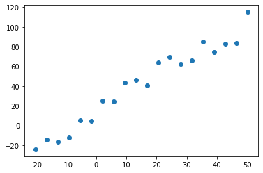

```python
plt.scatter(x, y)
```

This is equivalent to finding $m$, $c$ in the system:

$\begin{bmatrix} y_1 \\ y_2 \\ ... \\ y_n \end{bmatrix} \approx \begin{bmatrix} x_1 & 1 \\ x_2 & 1 \\ ... & ... \\ x_n & 1 \end{bmatrix} \begin{bmatrix} m \\ c \end{bmatrix} $

```python
A = np.vstack([x, np.ones(len(x))]).T
m, c = np.linalg.lstsq(A, y, rcond=None)[0]
m, c
```

```
(1.817240282830891, 14.051110940207312)
```

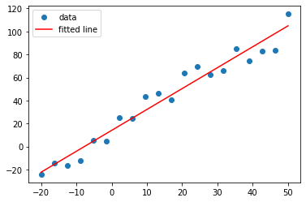

```python
plt.plot(x, y, 'o', label="data")
plt.plot(x, m * x + c, 'r', label="fitted line")
plt.legend()
```

# Getting & Setting elements

## Indexing

```python
a[1]
```

```
array([5, 6, 7, 8, 9])
```

```python
# Negative indices work too!
a[-1]
```

```
array([10, 11, 12, 13, 14])
```

```python
a[0, 1]
```

```
1
```

```python
a[:, 3]
```

```
array([ 3,  8, 13])
```

```python
a[0, 0] = 10.5
```

```python
a  # What's the problem here?
```

```
array([[10,  1,  2,  3,  4],
       [ 5,  6,  7,  8,  9],
       [10, 11, 12, 13, 14]])
```

### Slicing

- Works exactly the same way as slicing a list
- `array[lower:upper:step]` steps over `step` elements on the interval $[lower, upper)$
- This can be applied to multiple axis

```python
a[1:3]
```

```
array([[ 5,  6,  7,  8,  9],
       [10, 11, 12, 13, 14]])
```

```python
a[::2]
```

```
array([[10,  1,  2,  3,  4],
       [10, 11, 12, 13, 14]])
```

```python
a[::-1]
```

```
array([[10, 11, 12, 13, 14],
       [ 5,  6,  7,  8,  9],
       [10,  1,  2,  3,  4]])
```

```python
a[:, 1:3]
```

```
array([[ 1,  2],
       [ 6,  7],
       [11, 12]])
```

# Example: Blurring an Image

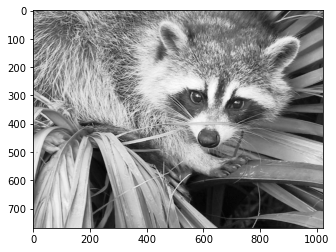

```python
face = misc.face(gray=True).astype(int)
plt.imshow(face, cmap="Greys_r")
```

```python
face
```

```
array([[114, 130, 145, ..., 119, 129, 137],
       [ 83, 104, 123, ..., 118, 134, 146],
       [ 68,  88, 109, ..., 119, 134, 145],
       ...,
       [ 98, 103, 116, ..., 144, 143, 143],
       [ 94, 104, 120, ..., 143, 142, 142],
       [ 94, 106, 119, ..., 142, 141, 140]])
```

```python
def smoothed_loop(img):
    smoothed = np.empty((img.shape[0] - 2, img.shape[1] - 2))
    for row in range(img.shape[0] - 2):
        for col in range(img.shape[1] - 2):
            smoothed[row, col] = (
                  img[row + 1, col + 1]  # center
                + img[row    , col + 1]  # top
                + img[row + 2, col + 1]  # bottom
                + img[row + 1, col    ]  # left
                + img[row + 1, col + 2]  # right
            ) / 5.0
    return smoothed
```

```python
img = smoothed_loop(face)
```

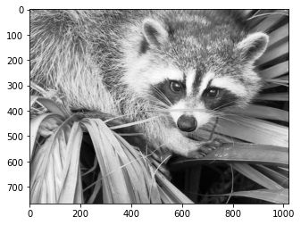

```python
plt.imshow(img, cmap='Greys_r')
```

```python
for _ in range(50):
    img = smoothed_loop(img)
```

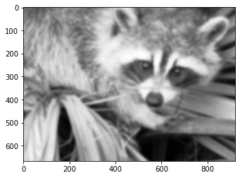

```python
plt.imshow(img, cmap='Greys_r')
```

```python
def smoothed_numpy(img):
    avg_img = (
          img[1: -1, 1: -1]  # center
        + img[:-2  , 1: -1]  # top
        + img[2:   , 1: -1]  # bottom
        + img[1:-1 ,  : -2]  # left
        + img[1:-1 , 2:   ]  # right
    ) / 5.0
    return avg_img
```

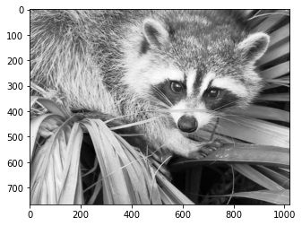

```python
img = smoothed_numpy(face)
plt.imshow(img, cmap='Greys_r')
```

## Timing comparisons

```python
%timeit smoothed_loop(face)
```

```
1.03 s ± 20.3 ms per loop (mean ± std. dev. of 7 runs, 1 loop each)
```

```python
%timeit smoothed_numpy(face)
```

```
1.92 ms ± 27 µs per loop (mean ± std. dev. of 7 runs, 1,000 loops each)
```

# Fancy Indexing

## Indexing by position

```python
a = rng.standard_normal(size=15)
a
```

```
array([ 0.63128823, -1.45715582, -0.31967122, -0.47037265, -0.63887785,
       -0.27514225,  1.49494131, -0.86583112,  0.96827835, -1.68286977,
       -0.33488503,  0.16275307,  0.58622233,  0.71122658,  0.79334724])
```

```python
a[[1, 3, 7]]
```

```
array([-1.45715582, -0.47037265, -0.86583112])
```

## Indexing with boolean masks

```python
a < 0
```

```
array([False,  True,  True,  True,  True,  True, False,  True, False,
        True,  True, False, False, False, False])
```

```python
negatives = a < 0
```

```python
a[negatives]
```

```
array([-1.45715582, -0.31967122, -0.47037265, -0.63887785, -0.27514225,
       -0.86583112, -1.68286977, -0.33488503])
```

# Broadcasting

```python
a = np.array([1.0, 2.0, 3.0])
b = np.array([2.0, 2.0, 2.0])
a + b
```

```
array([3., 4., 5.])
```

```python
a = np.array([1.0, 2.0, 3.0])
b = 2
a + b
```

```
array([3., 4., 5.])
```

[figure not shown]

## Broadcasting rules

- Compares the arrays shapes element wise
- starts with the trailing (rightmost) dimension
- works leftward
- two dimensions are compatible when:
  1. They are equal
  2. one of them is 1

```python
a = np.array([[ 0.0,  0.0,  0.0],
              [10.0, 10.0, 10.0],
              [20.0, 20.0, 20.0],
              [30.0, 30.0, 30.0]])
b = np.array([1.0, 2.0, 3.0])
a + b
```

```
array([[ 1.,  2.,  3.],
       [11., 12., 13.],
       [21., 22., 23.],
       [31., 32., 33.]])
```

[figure not shown]

## np.newaxis

```python
a.shape
```

```
(4, 3)
```

```python
a[np.newaxis]
```

```
array([[[ 0.,  0.,  0.],
        [10., 10., 10.],
        [20., 20., 20.],
        [30., 30., 30.]]])
```

```python
a[np.newaxis].shape
```

```
(1, 4, 3)
```

```python
a = np.array([0.0, 10.0, 20.0, 30.0])
b = np.array([1.0, 2.0, 3.0])
a[:, np.newaxis] + b
```

```
array([[ 1.,  2.,  3.],
       [11., 12., 13.],
       [21., 22., 23.],
       [31., 32., 33.]])
```

[figure not shown]

# Example: Pairwise Euclidean Distance

distance = $\sqrt{x_1^2 + x_2^2 + x_3^2}$

```python
points = rng.random(size=(1_000, 3))
```

```python
import math

def pdist_python(points):
    n = points.shape[0]
    distances = np.zeros((n, n))
    for i in range(n):
        for j in range(n):
            distances[i, j] =  math.dist(points[i], points[j])
    return distances
```

```python
def pdist_numpy(points):
    diff_squared = (points[np.newaxis, :] - points[:, np.newaxis]) ** 2
    distance_squared = np.sum(diff_squared, -1)
    distance = np.sqrt(distance_squared)
    return distance
```

```python
%timeit pdist_python(points)
```

```
839 ms ± 16.7 ms per loop (mean ± std. dev. of 7 runs, 1 loop each)
```

```python
%timeit pdist_numpy(points)
```

```
17.6 ms ± 282 µs per loop (mean ± std. dev. of 7 runs, 100 loops each)
```

# Extension: Why is NumPy faster?

## A Python Integer is more than an int

[figure not shown]

## A Python List is more than a list

[figure not shown]

## We can use this to our advantage!

- We only have to check the type of the array, not each element of the array
- The memory is contiguous
- The CPU can use SIMD instructions